# Retail Project

Abin John

23/05/2021

# Takeaway food services-New South Wales

The given data set is regarding the turnover of Takeway food service industry in New South Whales.

1.A discussion of the statistical features of the original data.

```
## Plot variable not specified, automatically selected `y = Turnover`
```

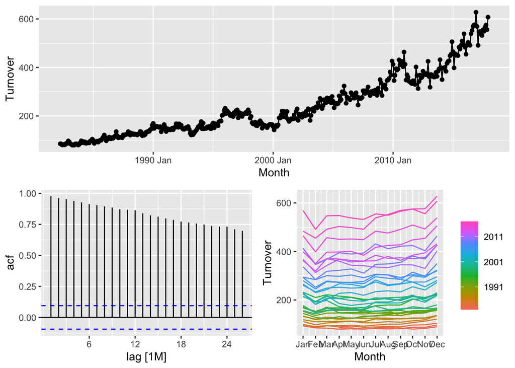

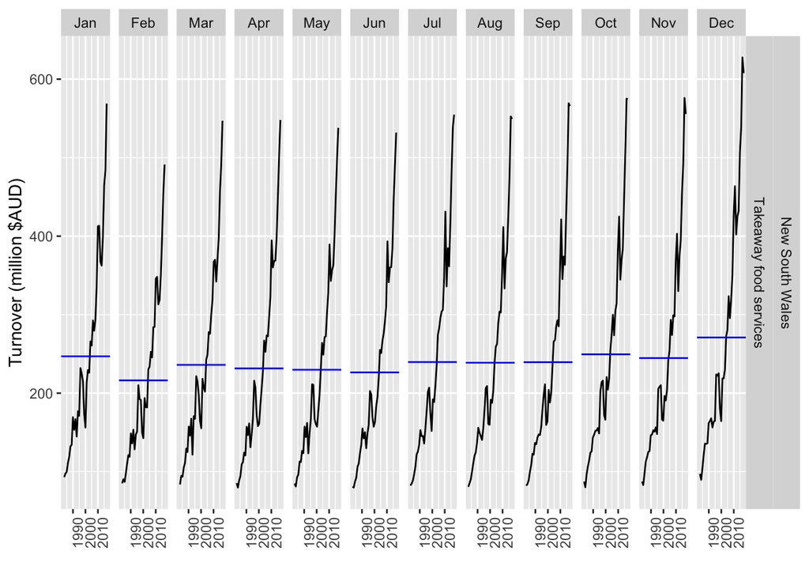

The retail data of New South Wales for ‘Takeaway food services’ industry has a clear upward trend in turnover from 1982 to up untill now.

The seasonality in the takeaway food industry has changed quite a lot from a moderately flat seasonal years.The data has a seasonal pattern which increases in size approximately proportionally to the Turnover. Therefore, the data has multiplicative seasonality.The recent years exhibits a seasonal sharp upward trend from February to March and then flattens through June .From June to July we can see a slight increase in seasonal trend .Also the data shows steep increase in seasonal trend from November to January where it reaches on the peak by December before it fall to the trough on February.

The data has small variance in the early years and higher variance in the later years .The variability in the data appears proportional to the amount of turnover (level of the series) over the time period.

In addition, the slow decrease in the lag of ACF plot suggests a clear non stationary data.

2.Explanation of transformations and differencing used. You should use a unit-root test as part of the discussion.

#ARIMA model In order to create arima models, first we need to make the data stationary . Here a log transformation can regularise the variance in the data.

log transformation

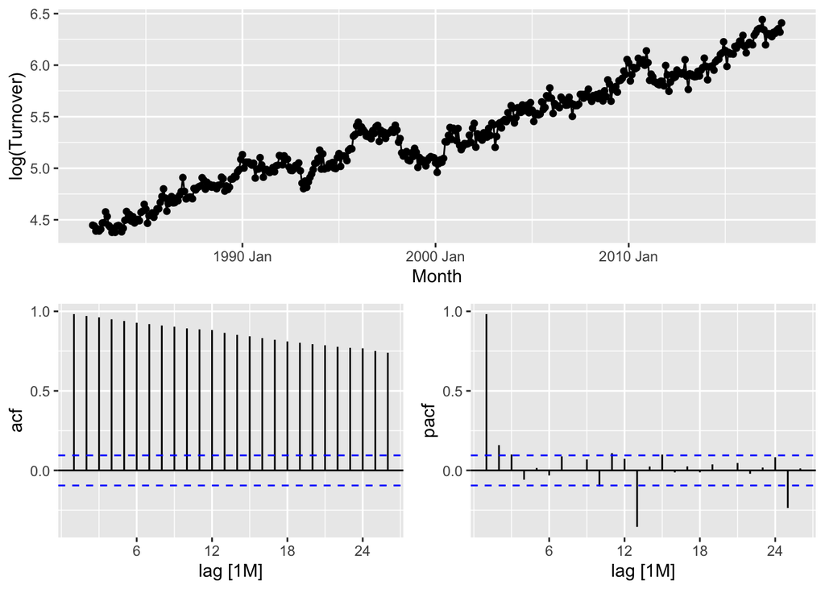

```
## # A tibble: 1 x 5
##   State           Industry               kpss_stat kpss_pvalue nsdiffs
##   <chr>           <chr>                      <dbl>       <dbl>   <int>
## 1 New South Wales Takeaway food services      6.85        0.01       1
```

The next step to make the data stationary is by doing a seasonal difference on the transformed data.

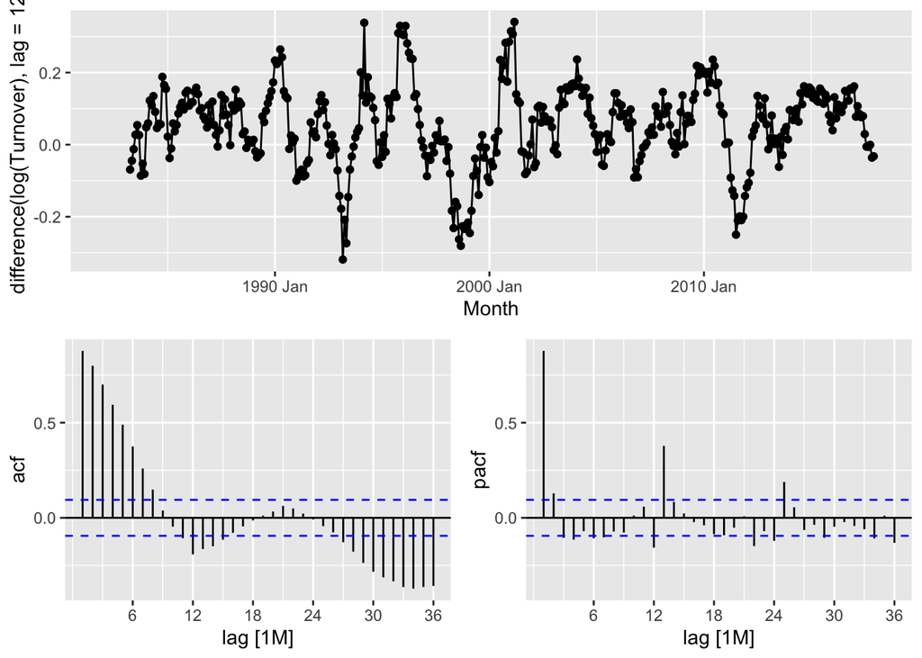

Here the Acf plot shows data drops to zero relatively quickly which suggests a stationary data and we can check whether a regular difference is needed using the Kpss unitroot test.

```
## # A tibble: 1 x 5
##   State           Industry               kpss_stat kpss_pvalue ndiffs
##   <chr>           <chr>                      <dbl>       <dbl>  <int>
## 1 New South Wales Takeaway food services    0.0803         0.1      0
```

Here the null hypothesis is that the data are stationary and non-seasonal. Since the p value 0.1 > 0.05 at 5% significance level we fail to reject the null hypothesis. But the Acf and Pacf plot shows several significant spikes so the data still looks non stationary.

First order differencing

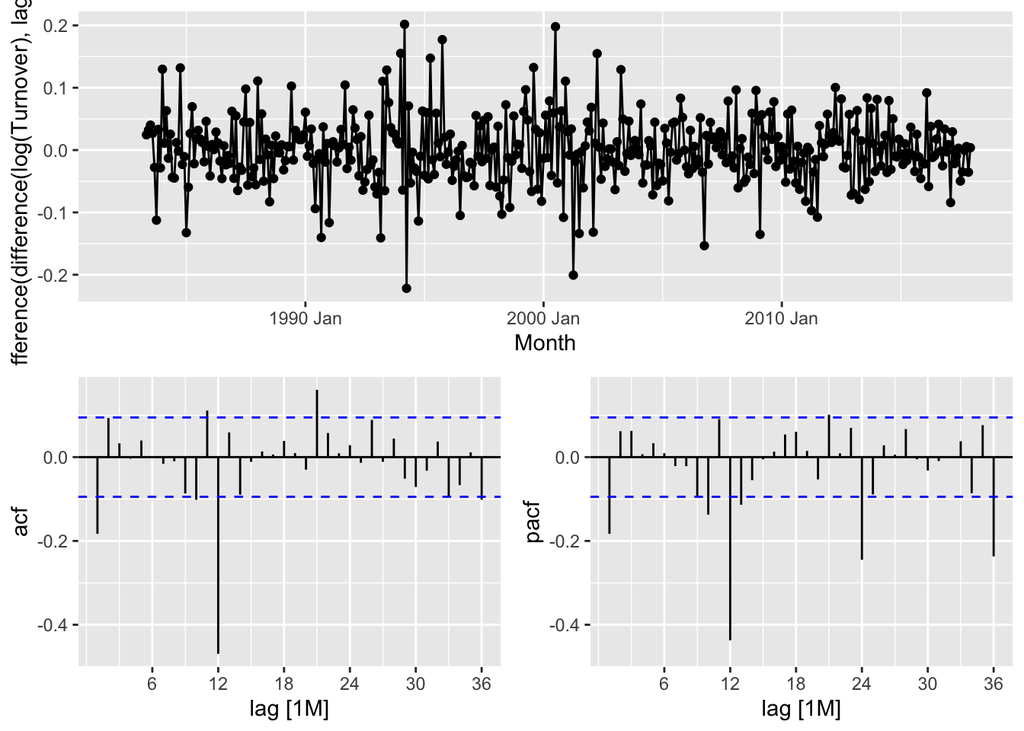

```
## # A tibble: 6 x 2
##   .model     AICc
##   <chr>     <dbl>
## 1 at_best  -1459.
## 2 at_ar    -1458.
## 3 ar011011 -1450.
## 4 ar110011 -1449.
## 5 ar110310 -1373.
## 6 ar011310 -1373.
```

```
## # A tibble: 6 x 2
##   .model    RMSE
##   <chr>    <dbl>
## 1 at_ar     9.49
## 2 at_best   9.59
## 3 ar011011  9.69
## 4 ar110011  9.70
## 5 ar110310 10.6
## 6 ar011310 10.6
```

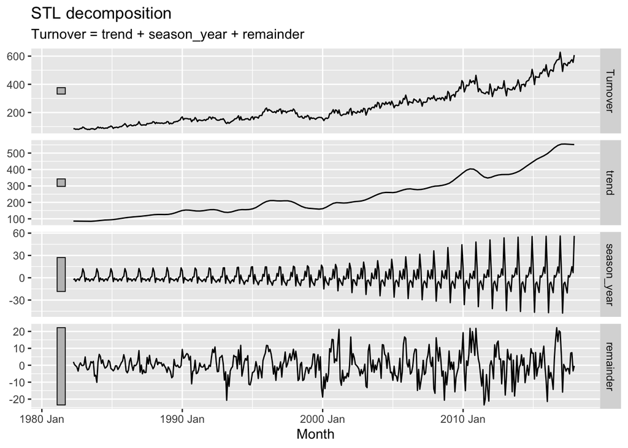

```
## # A tibble: 3 x 11
##   State   Industry   .model  sigma2 log_lik   AIC  AICc   BIC   MSE  AMSE    MAE
##   <chr>   <chr>      <chr>    <dbl>   <dbl> <dbl> <dbl> <dbl> <dbl> <dbl>  <dbl>
## 1 New So… Takeaway … auto   0.00175  -2220. 4476. 4477. 4549.  95.6  154. 0.0309
## 2 New So… Takeaway … madm   0.00175  -2220. 4476. 4477. 4549.  95.6  154. 0.0309
## 3 New So… Takeaway … mam    0.00181  -2228. 4491. 4492. 4560.  96.5  157. 0.0314
```

```
## # A tibble: 3 x 12
##   State Industry .model .type    ME  RMSE   MAE   MPE  MAPE  MASE RMSSE     ACF1
##   <chr> <chr>    <chr>  <chr> <dbl> <dbl> <dbl> <dbl> <dbl> <dbl> <dbl>    <dbl>
## 1 New … Takeawa… auto   Trai… 1.05   9.78  7.11 0.291  3.08 0.304 0.310 -0.00380
## 2 New … Takeawa… madm   Trai… 1.05   9.78  7.11 0.291  3.08 0.304 0.310 -0.00380
## 3 New … Takeawa… mam    Trai… 0.527  9.82  7.17 0.208  3.13 0.307 0.312  0.134
```

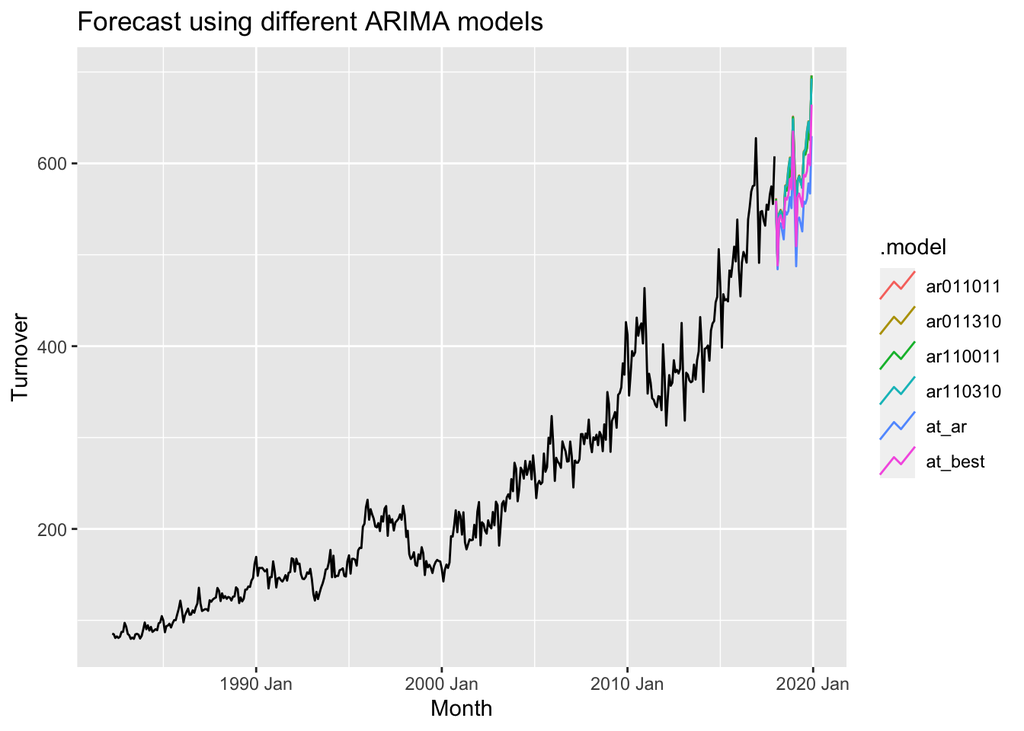

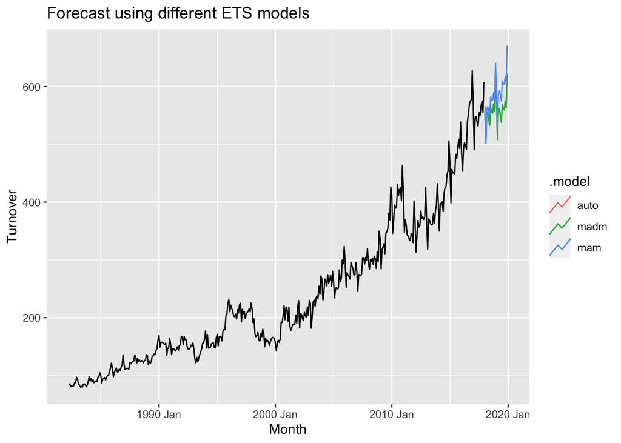

3.A description of the methodology used to create a short-list of appropriate ARIMA models and ETS models.

In order to shortlist ARIMA models , I have looked at the acf and pacf plot of the staionary data.Then I have chosen appropriate p,d,q, P,D,Q looking at the significant lags.In addition to this ,I have used an automatic selection of ARIMA model as well.

For the ETS model selection , I have looked at the gg_season and gg_subseries plot and decided to use multiplicative seasonality with both additive trend and additive damp trend.Also I have added an automatic selection ETS model which in turn picked the same model as I have manually chosen.

Include discussion of AIC values as well as results from applying the models to a test-set consisting of the last 24 months of data provided.

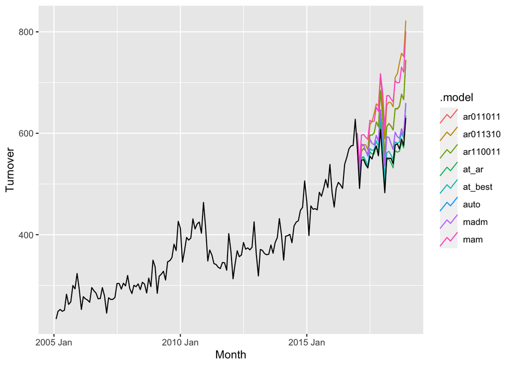

```
## # A tibble: 8 x 2
##   .model     AICc
##   <chr>     <dbl>
## 1 at_best  -1406.
## 2 at_ar    -1405.
## 3 ar011011 -1397.
## 4 ar110011 -1397.
## 5 ar011310 -1323.
## 6 auto      4327.
## 7 madm      4327.
## 8 mam       4346.
```

We cannot compare ETS and ARIMA models using same AICc value.Also the models we compare should have the same number of transformation and differencing applied.Here we can compare the ETS models as they all have same number of transformation and we can see that the madm model is having the lowest AICc among ETS models.We can say that madm will be the best ets model according to AICc .

```
## # A mable: 1 x 5
##                                at_ar                            at_best
##                              <model>                            <model>
## 1 <ARIMA(2,0,2)(0,1,1)[12] w/ drift> <ARIMA(2,0,0)(0,1,1)[12] w/ drift>
## # … with 3 more variables: ar110011 <model>, ar011011 <model>, ar011310 <model>
```

Here we can see that the order of difference for all ARIMA models are not same .So we cannot compare the ARIMA models using AICc.

```
## # A tibble: 8 x 12
##   .model State Industry .type     ME  RMSE   MAE     MPE  MAPE  MASE RMSSE  ACF1
##   <chr>  <chr> <chr>    <chr>  <dbl> <dbl> <dbl>   <dbl> <dbl> <dbl> <dbl> <dbl>
## 1 at_ar  New … Takeawa… Test   -2.07  10.2  8.11  -0.404  1.47 0.350 0.327 0.645
## 2 at_be… New … Takeawa… Test  -13.1   16.3 13.1   -2.37   2.37 0.567 0.521 0.563
## 3 auto   New … Takeawa… Test  -29.5   31.6 29.5   -5.37   5.37 1.27  1.01  0.641
## 4 madm   New … Takeawa… Test  -29.5   31.6 29.5   -5.37   5.37 1.27  1.01  0.641
## 5 ar011… New … Takeawa… Test  -56.9   62.8 56.9  -10.1   10.1  2.45  2.01  0.773
## 6 ar110… New … Takeawa… Test  -57.3   63.3 57.3  -10.2   10.2  2.47  2.03  0.776
## 7 mam    New … Takeawa… Test  -97.9  105.  97.9  -17.5   17.5  4.22  3.36  0.810
## 8 ar011… New … Takeawa… Test  -95.5  108.  95.5  -16.9   16.9  4.12  3.47  0.832
```

The best way to compare different models is by using RMSE value. Here we can see that ARIMA at_ar is the best model with the lowest RMSE.The Madm also have low RMSE.

The automatic ARIMA has picked up ARIMA(2,0,2)(0,1,1)[12] w/ drift as the best model for the data set.As far as the ETS model concerned, the training data set picked up MAdM as the best model.

Choose one ARIMA model and one ETS model based on this analysis and show parameter estimates, residual diagnostics, forecasts and prediction intervals for both models. Diagnostic checking for both models should include ACF graphs as well as the Ljung-Box test.

**Parameter estimates for the ARIMA model**

```
## Series: Turnover
## Model: ARIMA(2,0,2)(0,1,1)[12] w/ drift
## Transformation: log(Turnover)
##
## Coefficients:
##          ar1      ar2      ma1     ma2     sma1  constant
##       1.7674  -0.7816  -1.0119  0.2119  -0.8378     7e-04
## s.e.  0.1874   0.1774   0.1861  0.0559   0.0328     1e-04
##
## sigma^2 estimated as 0.00172:  log likelihood=709.53
## AIC=-1405.06   AICc=-1404.78   BIC=-1377.03
```

```
## Series: Turnover
## Model: ETS(M,Ad,M)
##   Smoothing parameters:
##     alpha = 0.7727478
##     beta  = 0.008796038
##     gamma = 0.07871687
##     phi   = 0.979925
##
##   Initial states:
##      l[0]      b[0]    s[0]     s[-1]    s[-2]    s[-3]    s[-4]    s[-5]
##  82.83243 0.4024296 1.00425 0.9514599 1.050413 1.078853 1.001372 1.008462
##      s[-6]     s[-7]     s[-8]    s[-9]    s[-10]    s[-11]
##  0.9798214 0.9952137 0.9954058 0.967956 0.9868042 0.9799897
##
##   sigma^2:  0.0018
##
##      AIC     AICc      BIC
## 4325.603 4327.322 4398.198
```

**ETS residual plot**

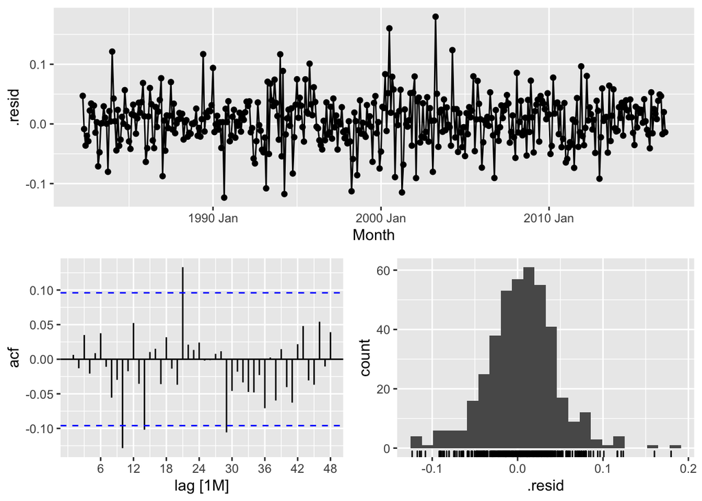

**Ljung-Box test**

```
## # A tibble: 1 x 3
##   .model lb_stat lb_pvalue
##   <chr>    <dbl>     <dbl>
## 1 madm      47.0    0.0330
```

**ARIMA parameter estimate**

```
## Series: Turnover
## Model: ARIMA(2,0,2)(0,1,1)[12] w/ drift
## Transformation: log(Turnover)
##
## Coefficients:
##          ar1      ar2      ma1     ma2     sma1  constant
##       1.7674  -0.7816  -1.0119  0.2119  -0.8378     7e-04
## s.e.  0.1874   0.1774   0.1861  0.0559   0.0328     1e-04
##
## sigma^2 estimated as 0.00172:  log likelihood=709.53
## AIC=-1405.06   AICc=-1404.78   BIC=-1377.03
```

**ARIMA residual plot**

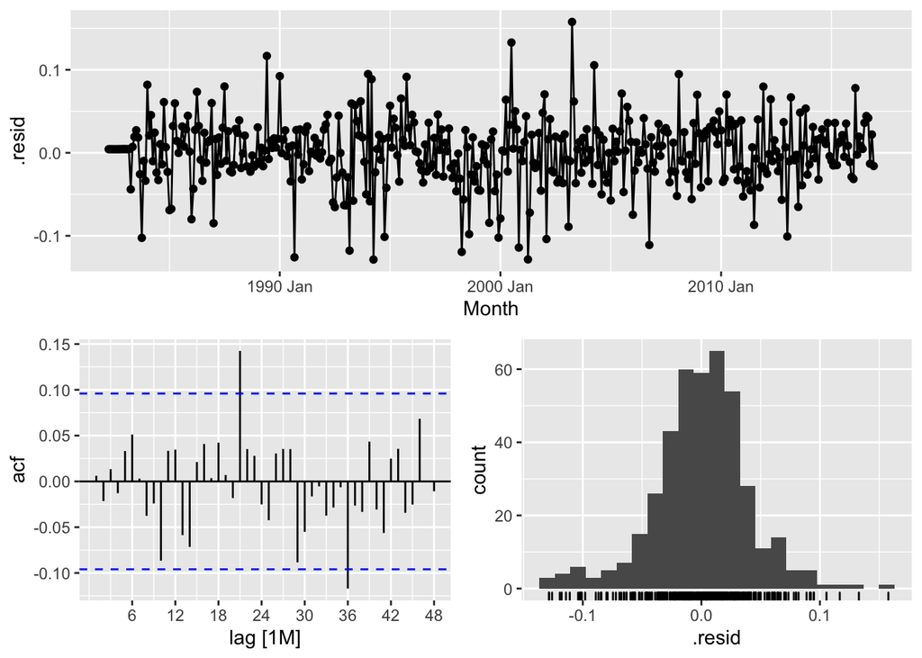

**Ljung-Box test**

```
## # A tibble: 1 x 3
##   .model lb_stat lb_pvalue
##   <chr>    <dbl>     <dbl>
## 1 at_ar     37.4     0.166
```

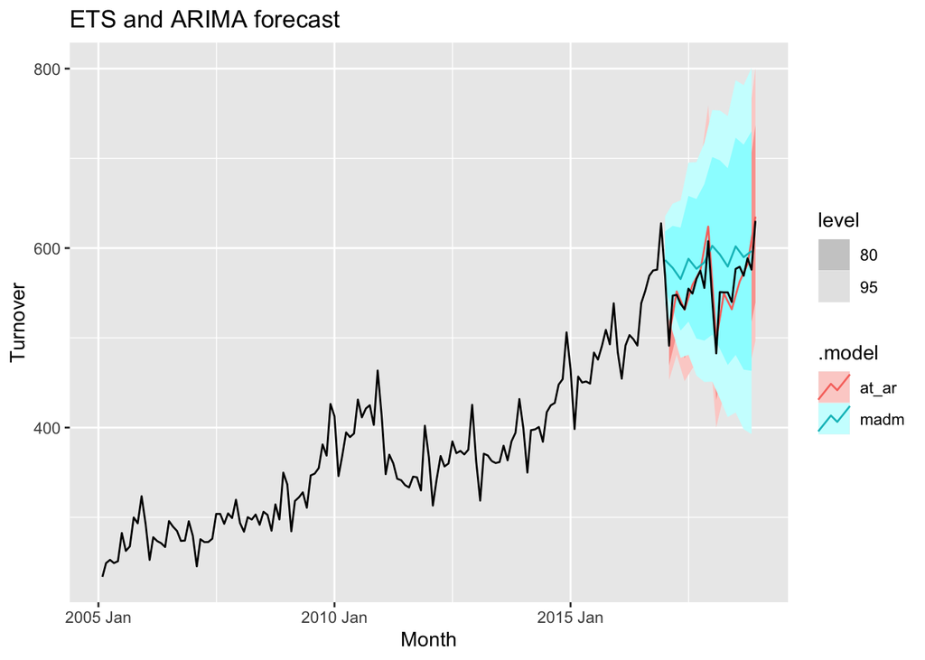

Comparison of the results from each of your preferred models. Which method do you think gives the better forecasts? Explain with reference to the test-set.

Here the ARIMA model ,at_ar (ARIMA(2,0,2)(0,1,1)[12] w/ drift ) looks better in forecasting the test set. It has almost followed the actual data.It has also picked up seasonality and trend well. The ETS model hasn’t picked up the seasonality well .It may be due to the fact that the model have captured a dominant trend in the data set.

Apply your two chosen models to the full data set and produce out-of-sample point forecasts and 80% prediction intervals for each model for two years past the end of the data provided.

```
## # A fable: 48 x 6 [1M]
## # Key:     State, Industry, .model [2]
##    State           Industry              .model    Month          Turnover .mean
##    <chr>           <chr>                 <chr>     <mth>            <dist> <dbl>
##  1 New South Wales Takeaway food servic… at_ar  2019 Jan t(N(6.4, 0.0016))  575.
##  2 New South Wales Takeaway food servic… at_ar  2019 Feb t(N(6.2, 0.0026))  503.
##  3 New South Wales Takeaway food servic… at_ar  2019 Mar t(N(6.3, 0.0035))  558.
##  4 New South Wales Takeaway food servic… at_ar  2019 Apr t(N(6.3, 0.0044))  560.
##  5 New South Wales Takeaway food servic… at_ar  2019 May t(N(6.3, 0.0052))  553.
##  6 New South Wales Takeaway food servic… at_ar  2019 Jun  t(N(6.3, 0.006))  544.
##  7 New South Wales Takeaway food servic… at_ar  2019 Jul t(N(6.4, 0.0067))  577.
##  8 New South Wales Takeaway food servic… at_ar  2019 Aug t(N(6.4, 0.0073))  575.
##  9 New South Wales Takeaway food servic… at_ar  2019 Sep t(N(6.4, 0.0079))  578.
## 10 New South Wales Takeaway food servic… at_ar  2019 Oct t(N(6.4, 0.0085))  595.
## # … with 38 more rows
```

**80% prediction intervals for two years**

```
## <hilo[48]>
##  [1] [545.3259, 604.8857]80 [470.4605, 536.0173]80 [515.9256, 600.4646]80
##  [4] [512.9456, 607.6977]80 [502.9138, 604.9362]80 [491.0337, 598.4784]80
##  [7] [518.3440, 639.0745]80 [513.7699, 639.8555]80 [513.6174, 645.3537]80
## [10] [526.5411, 666.7526]80 [513.9703, 655.2802]80 [567.0923, 727.3216]80
## [13] [514.4190, 665.8842]80 [449.0894, 585.5014]80 [497.2119, 652.3038]80
## [16] [498.3952, 657.4125]80 [492.1887, 652.2762]80 [483.6942, 643.6069]80
## [19] [513.6222, 685.7856]80 [511.8502, 685.4175]80 [514.2455, 690.3183]80
## [22] [529.5977, 712.3840]80 [519.1290, 699.4827]80 [574.9974, 775.8285]80
## [25] [551.4227, 613.0488]80 [484.2722, 554.0397]80 [533.0428, 624.6330]80
## [28] [527.2029, 631.0136]80 [512.2262, 625.0225]80 [496.2032, 616.3979]80
## [31] [520.3300, 657.3279]80 [509.6390, 654.1774]80 [501.8110, 654.0303]80
## [34] [510.2997, 674.9208]80 [495.1413, 664.2167]80 [542.0191, 737.1595]80
## [37] [495.2597, 684.7787]80 [438.1733, 613.7278]80 [484.8147, 687.6951]80
## [40] [481.3930, 691.3540]80 [469.1713, 682.0467]80 [455.6397, 670.3429]80
## [43] [478.7880, 712.7386]80 [469.7677, 707.4693]80 [463.2343, 705.6587]80
## [46] [471.6632, 726.6631]80 [458.1468, 713.7652]80 [501.9893, 790.7542]80
```

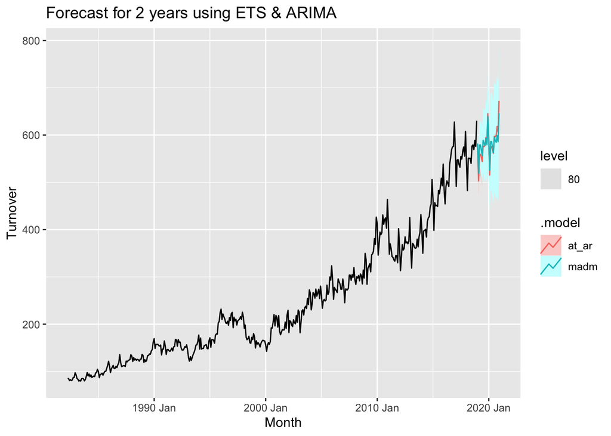

Obtain up-to-date data from the ABS website (Cat. 8501.0, Table 11), and compare your forecasts with the actual numbers. How well did you do? [Hint: the readabs package can help in getting the data into R.]

[output not shown]

```
## Finding URLs for tables corresponding to ABS catalogue 8501.0
```

```
## Attempting to download files from catalogue 8501.0, Retail Trade, Australia
```

```
## Extracting data from downloaded spreadsheets
```

```
## Tidying data from imported ABS spreadsheets
```

```
## Using `Month` as index variable.
```

```
## Plot variable not specified, automatically selected `.vars = Turnover`
```

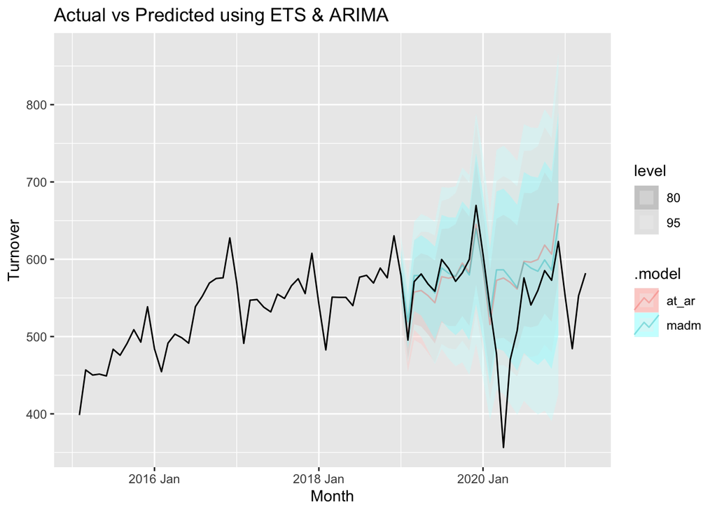

Both the ETS & ARIMA model has done a reasonably well until 2020. In fact, looking at the plot ETS(MAdM) model has done a slightly better job in predicting the forecast until 2020.The main reason for the disparity in actual data was due to the restrictions imposed in the takeaway food industry during Covid19 lock down.

A discussion of benefits and limitations of the models for your data.

Both the models have picked up the trend and seasonality in the dataset quite well.  
One of the drawbacks in these models is that it fails to respond to the unpredictable future events.In fact the actual data has occurred outside the prediction interval of both the models.